# Exploration and Visualization of Prosper loans

## Patrick Ojunde

- Introduction
- Objective
- Data Wrangling
- Univariate exploration
- Bivariate exploration
- Multivariate exploration
- General Summary & Insights
- Conclusion & Limtations

### Introduction

> The dataset is composed of 113,937 rows (uniquely idenifying a loan) and 81 variables that describes each loan some of which includes loan amount, borrower rate (or interest rate), current loan status, and borrower income.

> More information about this dataset can be found here: https://docs.google.com/spreadsheets/d/1gDyi_L4UvIrLTEC6Wri5nbaMmkGmLQBk-Yx3z0XDEtI/edit#gid=0

### Objective

> The objective of this analysis and visualization activity is to come up with interesting and actionable insghts from the loan data

> We also want to identify what featrues are suitable for predicting the success of a loan application

### Exlpore qualitative and quantitive features of datasets

```python
rows= df_main.shape[0]
columns = df_main.shape[1]
print(f'No of Rows: {rows}\nNo of Columns: {columns}')
```

```
No of Rows: 113937
No of Columns: 81
```

### Not all the data features are useful for our analysis, so we would work with the following `22 features`

### Useful Features for Predicting Outcome of a Loan Success

- Loan Term
- Loan Status
- Estimated Effective Yield
- Borrower APR
- Borrower (Loan) Rate
- Prosper (Credit) Rating (numeric)
- Prosper (Credit) Rating (Alpha)
- Prosper (Credit) Score
- Listing Category (numeric)
- EmploymentStatus
- Occupation
- Employment Status Duration
- Is Borrower Homeowner ?
- Verifiable Income
- Stated Monthly Income
- Monthly Loan Payment
- Recommendations
- Debt-to-Income-Ratio
- Loan Original Amount
- Income Range
- Investors
- Borrower State

#### Based on the intmacy gained from the data, and further research on loan outcomes and loan predictors, primacy of analysis would be given to features which cover factors like

> > - Borrowers income/employemnt status
> > - Borrowers debt exposure
> > - Borrowers asset (home owner in this instance)
> > - Credit rating from the loan company

> > [Reference](https://loans.usnews.com/articles/beyond-credit-scores-factors-that-affect-a-loan-application)

## Exploratory Data Analysis

## Univariate Exploration

### Applicants Income Range

> This helps us understand what income range most of our customers fall into

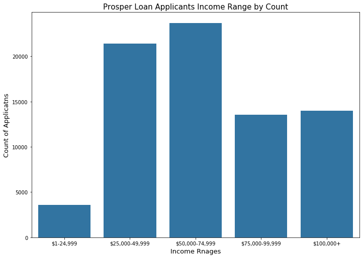

```python
plt.figure(figsize = (11.69,8.27))
sb.countplot(data = df_loan, x = 'income_range', color = bar_color);
plt.title('Prosper Loan Applicants Income Range by Count', fontsize=15)
plt.xlabel('Income Rnages',fontsize=13)
plt.ylabel('Count of Applicatns' ,fontsize=13)
plt.savefig(fname='visuals/income_ranges.png', format='png')
plt.show()
```

### One important question we might like to answer is the count of borrowers in our home oswers in our dataset

> This question provides a lof of financial insight into the exposure of the company

> It also helps us understand the ratio of secured loans to non-secured loans

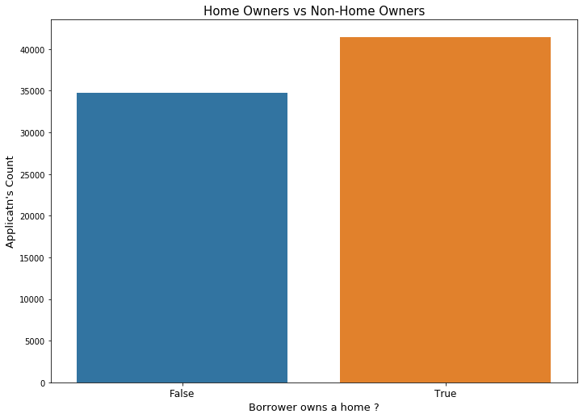

```python
plt.subplots(figsize=( 11.69,8.27))
plt.title("Home Owners vs Non-Home Owners", fontsize=15)
sb.countplot(df_loan.is_borrower_homeowner)
plt.ylabel('Applicatn\'s Count',fontsize=13)
plt.xlabel('Borrower owns a home ?' ,fontsize=13)
plt.xticks(fontsize=12)
plt.savefig(fname='visuals/home_owners.png', format='png')
plt.show()
```

### Distribution of Borrowers Monthly Income

> This plot helps us understand the distribution of borrowers monthly income

> It answers questions such as

> > Are majority of our labourers earn above averge income of all borrowers

> > This means that there are more borrowers who earn less than the average income of all borrowers combines

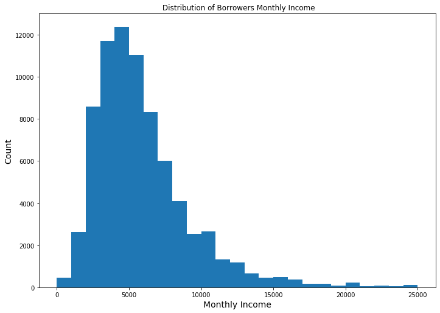

```python
low_income = df_loan[df_loan['stated_monthly_income'] <= 25000]
bin_edges = np.arange(0, low_income.stated_monthly_income.max()+1000, 1000)
plt.figure(figsize=[ 11.69,8.27])
plt.hist(data = df_loan, x = 'stated_monthly_income', bins = bin_edges);
plt.xlabel('Monthly Income', fontsize=14)
plt.ylabel('Count', fontsize=14)
plt.title(" Distribution of Borrowers Monthly Income")
plt.savefig(fname='visuals/borrowers_monthly_distro.png', format='png')
plt.show()
```

## Bivariate Exploration

> In this section,I would be investigating relationships between pairs of variables in our data

> In this section, I would be taking my amalysis further by trying to understad anf visalizse the relationships between two different varibles and how this affects the outomce of a loan application

#### Income range effect on loan amount

> These chart helps us understand how high or low income ranges affects approved loan amount of borrowers

> > The charts below shows us that higher income ranges is likely to lead to increase approved loan amounts

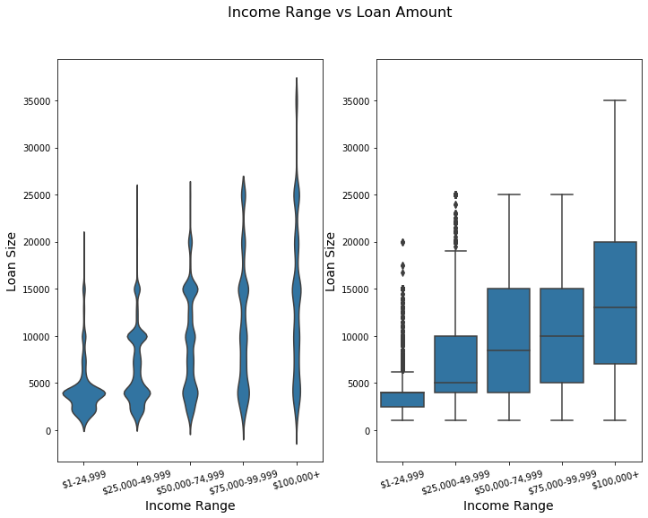

```python
plt.figure(figsize = [11.69,8.27])

# violin plot
plt.subplot(1, 2, 1)
ax1 = sb.violinplot(data = df_loan, x = 'income_range', y = 'loan_original_amount', color = bar_color,inner=None)
plt.xticks(rotation = 15);
plt.ylabel('Loan Size', fontsize=14)
plt.xlabel('Income Range', fontsize=14)

# box plot
plt.subplot(1, 2, 2)
sb.boxplot(data = df_loan, x = 'income_range', y = 'loan_original_amount', color = bar_color)
plt.ylim(ax1.get_ylim()) # set y-axis limits to be same as left plot
plt.xticks(rotation = 15);
plt.ylabel('Loan Size', fontsize=14)
plt.xlabel('Income Range', fontsize=14)
plt.suptitle('Income Range vs Loan Amount', fontsize=16)
plt.savefig(fname='visuals/inceom_range_loan_size.png', format='png')
```

#### Loan Status Vs. Employment Status

> The chart below helps us understand how emplyment status affects loan status

> > Our observations about this are made after the chart below

[figure not shown]

```python
plt.figure(figsize = [11.69,8.27])
sb.heatmap(employ_loan_status, annot = True,fmt='2g');
plt.title('Effect of Employment Status on Loan Status', fontsize=16)
plt.ylabel('Loan Status', fontsize=14)
plt.xlabel('Employment Status', fontsize=14)
plt.suptitle('Income Range vs Loan Amount', fontsize=16)
plt.savefig(fname='visuals/loan_vs_employ_status.png', format='png')
plt.show()
```

#### Observation

> > Majority of applicatns who have current & completed loans, falls under the Employed & Full-time Employment Status

#### Home Ownership Status and Loan Status

> In this chart, we want to explore the relationship between Borrowers' Home Ownership status and Loan Status

> > Our observations about this are made after the chart below

> > Group Home Ownership by Loan Status

[figure not shown]

```python
plt.figure(figsize = [ 11.69,8.27])
sb.heatmap(home_loan_status, annot = True, fmt = 'd');
plt.title('Effect of Home Ownership on Loan Status', fontsize=16)
plt.ylabel('Loan Status', fontsize=14)
plt.yticks(fontsize=13)
plt.xlabel('Owns a Home?', fontsize=14)
plt.xticks(fontsize=13)
plt.suptitle('Income Range vs Loan Amount', fontsize=16)
plt.savefig(fname='visuals/loan_vs_home_status.png', format='png')
plt.show()
```

### Observation

> > Majority of borrowers in Comlpeted or Current Loan Status owns a home

### Key Insights & Summary of Findings from Bivariate Analysis

- Not only are there more positive outcome of loan application by employed borrowers, borrowers with AA rating are also fully employed
- A large chunkc of the employed borrowers earn between 50K USD
- Most of the Borrowers with Completed Loan Status are employed Borrowers
- Individuals that earn above $100K have the highest median loan orginal amount

### Multivariate Exploration

> In this section, we would be creating plots of three or more variables to investigate our data even further

#### Effect Income Range & Credit Rating on Loan Original Amount

> We want to understand the effect of the Interaction of Income Ranges and Credit Rating on Loan Original Amount

> What informs borrowers decsion on the amount of loan to ask for. Are these factors useful at predictiong such

> > We would be plotting our charts based on the first three catgories of credit rrating

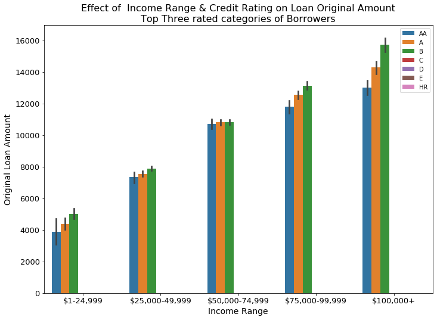

```python
plt.figure(figsize = [ 11.69,8.27])

ax = sb.barplot(data = df_loan_less2, x = 'income_range', y = 'loan_original_amount', hue = 'prosper_alpha_rating')
ax.legend(loc = 8, ncol = 3, framealpha = 1, title = 'prosper_rating_alpha')
plt.title('Effect of  Income Range & Credit Rating on Loan Original Amount\nTop Three rated categories of Borrowers', fontsize=16)
plt.ylabel('Original Loan Amount', fontsize=14)
plt.yticks(fontsize=13)
plt.xlabel('Income Range', fontsize=14)
plt.xticks(fontsize=13)
plt.legend(loc=1)
plt.savefig(fname='visuals/income_vs_amount_top3rated.png', format='png')
plt.show()
```

#### Effect of having a home and high credit rating on borrower's Loan Insterest Rate

[figure not shown]

```python
plt.figure(figsize=[ 11.69,8.27])
sb.boxplot(data = df_loan_less, x = 'prosper_alpha_rating', y = 'borrower_rate',hue='is_borrower_homeowner')
plt.xticks(rotation = 15)
plt.title(' Effect of Having a Home and High Credit Rating\non borrower\'s Loan Interest Rate')
plt.xlabel('Employment Status', fontsize=14)
plt.xticks(fontsize=13)
plt.ylabel('Loan Amount', fontsize=14)
plt.yticks(fontsize=13)
plt.savefig(fname='visuals/home_vs_creditRating_loanAmonunt.png', format='png')
plt.show()
```

### Conclusion & Limitations

One Limitation of this Exploratory Data Analysis is there are no delibeberte statistical analysis. The objective of the project lats more emphasis on the visualization aspect.

Statistical Analysis like Linear/logistic Regression woudl prove a value addition to the project but is quite beyond the scope of this project.

In conclusion, based on the various visualizations made in this notebook, factors for predicting succesful laon application include:

- Borrower's Home Ownership
- Borrower's Employment Status
- Borrower's Monthly Income
- Borrower's prosper (credit) rating